*Python Machine Learning 3rd Edition* by [Sebastian Raschka](https://sebastianraschka.com), Packt Publishing Ltd. 2019

Code Repository: https://github.com/rasbt/python-machine-learning-book-3rd-edition

Code License: [MIT License](https://github.com/rasbt/python-machine-learning-book-2nd-edition/blob/master/LICENSE.txt)

# Homework 2 - INFO 5604

## From Canvas

For HW 2, use the roadmap for building machine learning systems and the sklearn library, train a decison tree with a maximum depth of 5 using Entropy impurity as a criterion for impurity. Perform and document each step of the roadmap (including learning and evaluation). For full credit, you must include all cells in your .ipynb that we covered in ICHW 2 (DT, step 1 - 6 cleary marked and annotated ). This is not a "cut and paste' homework. You must think about what you are doing.

Also, answer the following questions: How many dimensions does plot_decision_regions function works for? What is the maximum accuracy you can achieve with the least amount of features? How does the depth of the tree affect accuracy (try a couple of depths)?

After you have completed HW2, upload and submit your files.

# Decision tree learning

```python
from IPython.display import Image
%matplotlib inline

# Image(filename='images/03_17.png', width=500)
```

```python
import numpy as np
import pandas as pd
from matplotlib import pyplot as plt
import seaborn as sns
import statsmodels.api as sm
import scipy.stats as stats
from sklearn.preprocessing import LabelEncoder
import copy
sns.set()
```

```python
# define plot_decision_regions for later use
```

```python
from matplotlib.colors import ListedColormap
import matplotlib.pyplot as plt

# To check recent matplotlib compatibility
import matplotlib
from distutils.version import LooseVersion


def plot_decision_regions(X, y, classifier, test_idx=None, resolution=0.02):

    # setup marker generator and color map
    markers = ('s', 'x', 'o', '^', 'v')
    colors = ('red', 'blue', 'lightgreen', 'gray', 'cyan')
    cmap = ListedColormap(colors[:len(np.unique(y))])

    # plot the decision surface
    x1_min, x1_max = X[:, 0].min() - 1, X[:, 0].max() + 1
    x2_min, x2_max = X[:, 1].min() - 1, X[:, 1].max() + 1
    xx1, xx2 = np.meshgrid(np.arange(x1_min, x1_max, resolution),
                           np.arange(x2_min, x2_max, resolution))
    Z = classifier.predict(np.array([xx1.ravel(), xx2.ravel()]).T)
    Z = Z.reshape(xx1.shape)
    plt.contourf(xx1, xx2, Z, alpha=0.3, cmap=cmap)
    plt.xlim(xx1.min(), xx1.max())
    plt.ylim(xx2.min(), xx2.max())

    for idx, cl in enumerate(np.unique(y)):
        plt.scatter(x=X[y == cl, 0],
                    y=X[y == cl, 1],
                    alpha=0.8,
                    color=colors[idx],
                    marker=markers[idx],
                    label=cl,
                    edgecolor='black')

    # highlight test examples
    if test_idx:
        # plot all examples
        X_test, y_test = X[test_idx, :], y[test_idx]


        if LooseVersion(matplotlib.__version__) < LooseVersion('0.3.4'):
            plt.scatter(X_test[:, 0],
                        X_test[:, 1],
                        c='',
                        edgecolor='black',
                        alpha=1.0,
                        linewidth=1,
                        marker='o',
                        s=100,
                        label='test set')
        else:
            plt.scatter(X_test[:, 0],
                        X_test[:, 1],
                        c='none',
                        edgecolor='black',
                        alpha=1.0,
                        linewidth=1,
                        marker='o',
                        s=100,
                        label='test set')
```

[figure not shown]

# Load the MedTrial dataset

```python
import numpy as np
import pandas as pd

s = 'MedTrial.csv'
# print('URL:', s)

df = pd.read_csv(s)
df
```

|  | Age | Sex | BP | Cholesterol | Na_to_K | Med |
| --- | --- | --- | --- | --- | --- | --- |
| 0 | 23 | F | HIGH | HIGH | 25.355 | Yipic |
| 1 | 47 | M | LOW | HIGH | 13.093 | Comodify |
| 2 | 47 | M | LOW | HIGH | 10.114 | Comodify |
| 3 | 28 | F | NORMAL | HIGH | 7.798 | Xlenify |
| 4 | 61 | F | LOW | HIGH | 18.043 | Yipic |
| ... | ... | ... | ... | ... | ... | ... |
| 195 | 56 | F | LOW | HIGH | 11.567 | Comodify |
| 196 | 16 | M | LOW | HIGH | 12.006 | Comodify |
| 197 | 52 | M | NORMAL | HIGH | 9.894 | Xlenify |
| 198 | 23 | M | NORMAL | NORMAL | 14.020 | Xlenify |
| 199 | 40 | F | LOW | NORMAL | 11.349 | Xlenify |

200 rows × 6 columns

## Perform Exploratory Data Analysis according to ICHW 1

### Find the different classes, number of classes, and the number of samples within each class from ICHW1/HW1

```python
classes = pd.unique(df['Med'])
num_classes = len(classes)
each_class = df['Med'].value_counts()

print(classes)
print(num_classes)
print(each_class)

print(df.info())
```

```
['Yipic' 'Comodify' 'Xlenify' 'Abelify' 'Bulity']
5
Yipic       91
Xlenify     54
Abelify     23
Comodify    16
Bulity      16
Name: Med, dtype: int64
<class 'pandas.core.frame.DataFrame'>
RangeIndex: 200 entries, 0 to 199
Data columns (total 6 columns):
 #   Column       Non-Null Count  Dtype
---  ------       --------------  -----
 0   Age          200 non-null    int64
 1   Sex          200 non-null    object
 2   BP           200 non-null    object
 3   Cholesterol  200 non-null    object
 4   Na_to_K      200 non-null    float64
 5   Med          200 non-null    object
dtypes: float64(1), int64(1), object(4)
memory usage: 9.5+ KB
None
```

**How many samples do we have?** There are 200 samples (0-indexed, so 199+1 = 200 total samples from the dataset output)

**How many features do we have?** We have five features total

**What are the classes?** I'm assuming that this CSV file/datset is structured in the same way as ICHW1. That is, the classes are in the last column of the dataset, with the features in the preceding columns. The classes, therefore, would be the kind of medication that the patient is on. Here, that would be Yipic, Comodify, Xlenify, Abelify, and Bulity.

**How many classes do we have?** Five (see the output below the array that starts with `['Yipic' 'Comodify']`, etc.)

**How many samples of each class? are they balanced?** Yipic: 91 Xlenify: 54 Abelify: 23 Comodify: 16 Bulity: 16

Because some classes have more than others (i.e. Yipic has many more samples than Bulity), these classes are not balanced.

### Check missing values, outliers, and statistics

```python
df.isna().apply(pd.value_counts)
```

|  | Age | Sex | BP | Cholesterol | Na_to_K | Med |
| --- | --- | --- | --- | --- | --- | --- |
| False | 200 | 200 | 200 | 200 | 200 | 200 |

**Are there anomolies in the statistics?** Yes. As can be seen in the boxplot below, only the continuous values of Age and Na_to_K are plotted. It would make the most sense to change the features like BP from "NORMAL", "HIGH", and "LOW" to a numerical scheme. I'll do that below the boxplot.

**Are there outliers?** Yes, in the Na_to_K boxplot below, we can see that there are several outliers. I'll set any values that are outliers to be the 75th percentile.

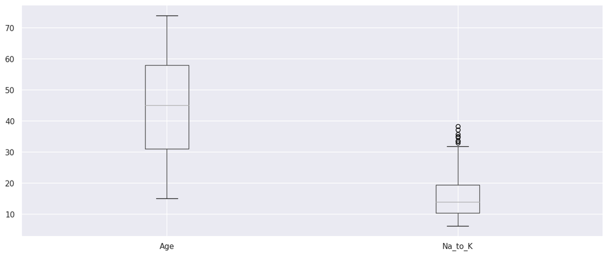

|  | count | mean | std | min | 25% | 50% | 75% | max |
| --- | --- | --- | --- | --- | --- | --- | --- | --- |
| Age | 200.0 | 44.315000 | 16.544315 | 15.000 | 31.0000 | 45.0000 | 58.00 | 74.000 |
| Na_to_K | 200.0 | 16.084485 | 7.223956 | 6.269 | 10.4455 | 13.9365 | 19.38 | 38.247 |

```python
df.boxplot(figsize = (15,6))
plt.show()
df.describe().T
```

Changes to make to the dataset:

1. Change the "Sex" column to the following:

"M": 0 "F": 1

2. Change the "BP" column to the following:

"LOW": 0 "NORMAL": 1 "HIGH": 2

3. Change the "Cholesterol" column to the following:

"LOW": 0 "NORMAL": 1 "HIGH": 2

```python
# Implementing step 1
sex_dict = {"M": 0, "F": 1}
df['Sex'] = df['Sex'].replace(sex_dict)

# Implementing step 2
bp_dict = {"LOW": 0, "NORMAL": 1, "HIGH": 2}
df['BP'] = df['BP'].replace(bp_dict)

# Implementing step 3
chol_dict = {"LOW": 0, "NORMAL": 1, "HIGH": 2}
df['Cholesterol'] = df['Cholesterol'].replace(chol_dict)

# Implementing step 4
percentile = 19.38
df.loc[df['Na_to_K'] >= percentile, 'Na_to_K'] = percentile
```

### Check distributions and correlations

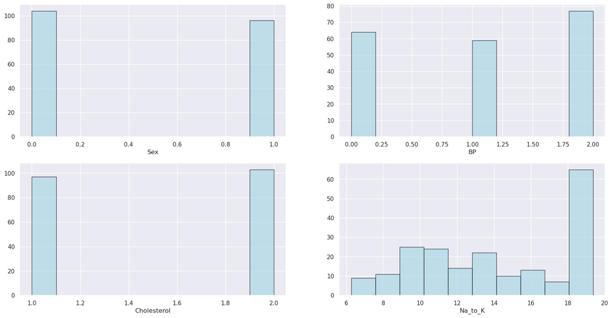

```python
plt.figure(figsize= (20,10))
plt.subplot(2, 2, 1)
plt.hist(df['Sex'], color='lightblue', edgecolor = 'black', alpha = 0.7)
plt.xlabel('Sex')

plt.subplot(2, 2, 2)
plt.hist(df['BP'], color='lightblue', edgecolor = 'black', alpha = 0.7)
plt.xlabel('BP')

plt.subplot(2,2,3)
plt.hist(df['Cholesterol'], color='lightblue', edgecolor = 'black', alpha = 0.7)
plt.xlabel('Cholesterol')

plt.subplot(2,2,4)
plt.hist(df['Na_to_K'], color='lightblue', edgecolor = 'black', alpha = 0.7)
plt.xlabel('Na_to_K')
plt.show()
```

**What kind of distributions do the features have?**

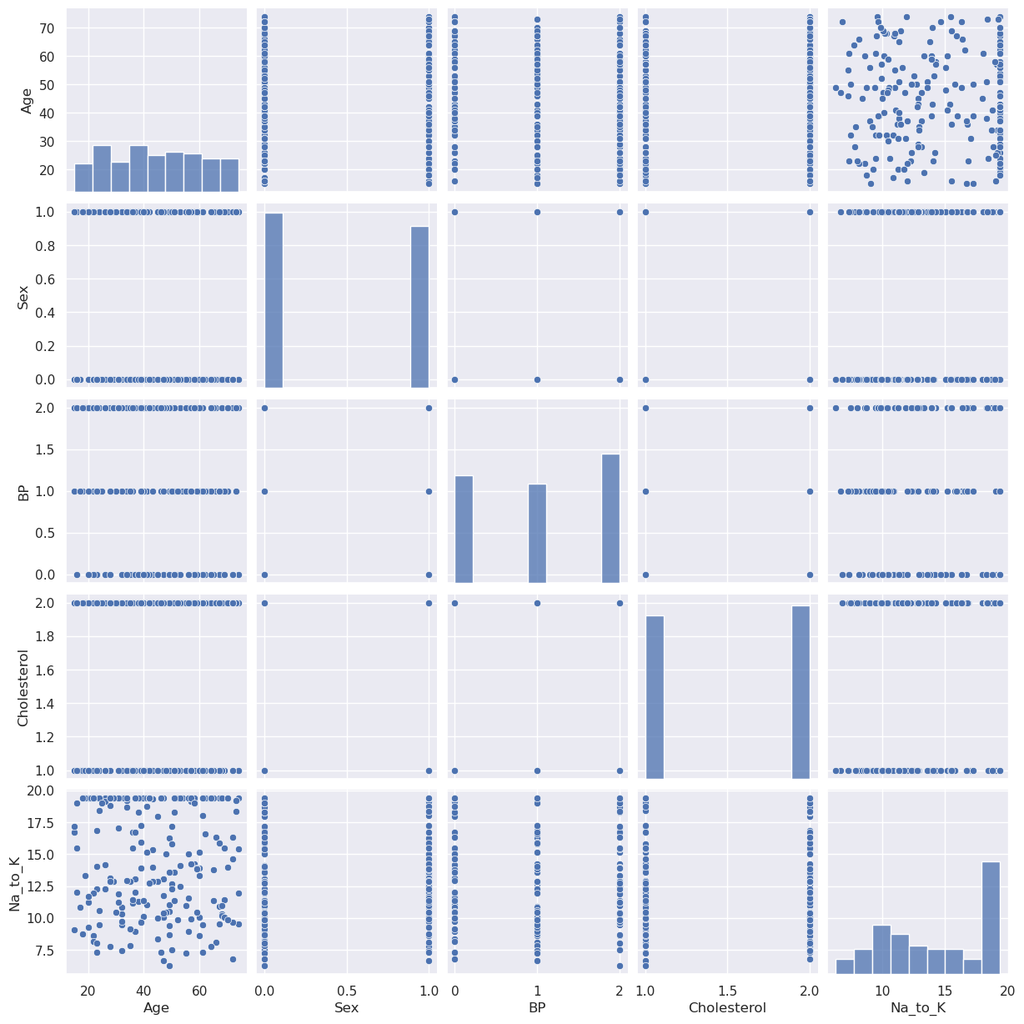

```python
sns.pairplot(df)  #pairplot
plt.show()
```

**What kind of correlation does the data exhibit?**

It doesn't appear that there is any strong correlation within the data. This can be seen both by the scatter plot above but also by the heatmap below.

```python
df.corr()
```

|  | Age | Sex | BP | Cholesterol | Na_to_K |
| --- | --- | --- | --- | --- | --- |
| Age | 1.000000 | -0.102027 | -0.120918 | 0.068234 | -0.043854 |
| Sex | -0.102027 | 1.000000 | 0.044952 | -0.008811 | 0.140351 |
| BP | -0.120918 | 0.044952 | 1.000000 | -0.032208 | 0.037017 |
| Cholesterol | 0.068234 | -0.008811 | -0.032208 | 1.000000 | 0.018142 |
| Na_to_K | -0.043854 | 0.140351 | 0.037017 | 0.018142 | 1.000000 |

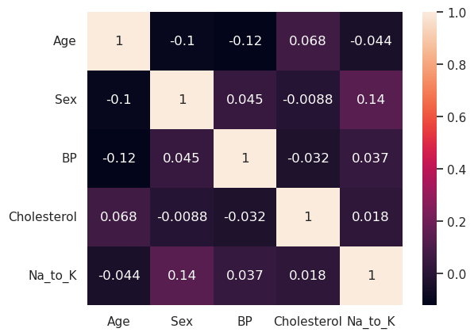

```python
sns.heatmap(df.corr(), annot = True)
plt.show()
```

# Steps to build ML model in sklean

## Arrange the data into featues and target arrays.

Based on our `plot_decision_regions` function defined above, we can only use two features for our model. While we do have more, by only using two, we can plot the decision region to see how well our model is performing from a visual perspective.

I'm going to choose the two continuous variables, `Age` and `Na_to_K`, mostly arbitrarily but what limited intuition I have makes me think that continuous variables may capture subtleties in the data that categorical variables like `Sex` might not.

Well, I tried that and the model didn't train well at all. Looking back at what we did during ICHW2, we picked the two features that have a really high correlation with each other (`petal_length` and `petal_width` have a correlation coefficient of 0.96). Our dataset doesn't have such a strong correlation anywhere. I'll try using the two features that correlate with each other the most `Sex` and `Na_to_K`) just to see what happens. If that doesn't work I'll throw more features at the problem and see if the accuracy score improces.

```python
# extract Sex and Na_to_K
X = df.iloc[:, [1, 4]].values
y = df.iloc[:, 5]

# print(X)
# print(y)

# print(df.columns)
```

```python
# change y from categorical to numeric
y = pd.factorize(df['Med'])[0]
print(y)
```

```
[0 1 1 2 0 2 0 1 0 0 1 0 0 0 2 0 2 3 1 0 0 0 0 0 0 0 0 2 0 0 2 4 2 0 2 2 3
 2 2 2 0 4 0 2 2 2 3 1 0 0 0 2 0 0 4 1 4 0 2 0 0 3 0 2 4 0 3 2 0 0 4 0 2 0
 0 0 3 0 3 2 4 2 1 3 1 4 2 0 0 0 0 0 0 0 0 2 0 0 0 0 3 3 1 2 0 2 2 0 4 0 3
 2 2 2 2 0 2 2 3 0 0 0 0 0 4 0 0 2 0 2 0 0 2 0 0 2 4 3 4 2 3 0 4 0 3 2 2 3
 2 1 3 4 2 2 0 1 3 0 1 2 2 4 2 0 0 0 0 2 0 3 2 2 0 0 3 0 3 0 0 0 0 2 2 0 0
 0 4 3 0 0 0 3 0 1 0 1 1 2 2 2]
```

```python
# 2. Split data into a training set and test set
#    Splitting data into 70% training and 30% test data:
```

```python
from sklearn.model_selection import train_test_split

X_train, X_test, y_train, y_test = train_test_split(
    X, y, test_size=0.3, random_state=1, stratify=y)
```

```python
print('Labels count in y:', np.bincount(y))
print('Labels count in y_train:', np.bincount(y_train))
print('Labels count in y_test:', np.bincount(y_test))
```

```
Labels count in y: [91 16 54 23 16]
Labels count in y_train: [64 11 38 16 11]
Labels count in y_test: [27  5 16  7  5]
```

```python
# 3. Select the ML algorithm, and its parameteters
```

```python
from sklearn.tree import DecisionTreeClassifier

tree_model = DecisionTreeClassifier(criterion='entropy',
                                    max_depth=5,
                                    random_state=1)
```

```python
# 4. Build the model (.fit)
```

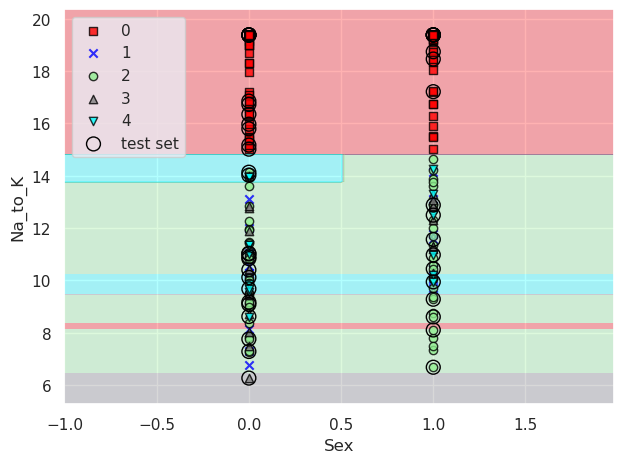

```python
tree_model.fit(X_train, y_train)

X_combined = np.vstack((X_train, X_test))
y_combined = np.hstack((y_train, y_test))
plot_decision_regions(X_combined, y_combined,
                      classifier=tree_model,
                      test_idx=range(105, 150))

plt.xlabel('Sex')
plt.ylabel('Na_to_K')
plt.legend(loc='upper left')
plt.tight_layout()
#plt.savefig('images/03_20.png', dpi=300)
plt.show()
```

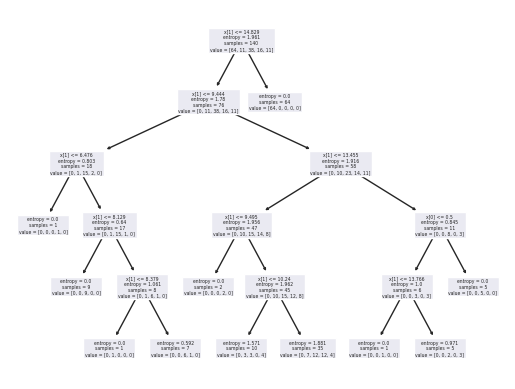

```python
from sklearn import tree

tree.plot_tree(tree_model)
#plt.savefig('images/03_21_1.pdf')
plt.show()
```

```python
# make it nice
```

```python
%pip install pydotplus
from pydotplus import graph_from_dot_data
from sklearn.tree import export_graphviz

dot_data = export_graphviz(tree_model,
                           filled=True,
                           rounded=True,
                           class_names=['Yipic', 'Comodify', 'Xlenify',
                                        'Abelify', 'Bulity'],
                           feature_names=['Age',
                                          'Na_to_K'],
                           out_file=None)
graph = graph_from_dot_data(dot_data)
graph.write_png('tree.png')
```

```
True
```

```python
# Image(filename='images/03_21.png', width=600)
```

```python
# 5. Apply the model to the test data (.predict)
# 6. Estimate performance (accuracy score)
```

```python
from sklearn import metrics
y_pred = tree_model.predict(X_test)
print(metrics.accuracy_score(y_test, y_pred))
```

```
0.6333333333333333
```

## Combining weak to strong learners via random forests

[figure not shown]

[output not shown]

[output cut: 1023 more lines]

[output not shown]

```python
from sklearn.ensemble import RandomForestClassifier
from sklearn.tree import plot_tree


forest = RandomForestClassifier(criterion='entropy',
                                n_estimators=25,
                                random_state=1,
                                n_jobs=2)
forest.fit(X_train, y_train)

plot_decision_regions(X_combined, y_combined,
                      classifier=forest, test_idx=range(105, 150))

plt.xlabel('Age')
plt.ylabel('Na_to_K')
plt.legend(loc='upper left')
plt.tight_layout()
#plt.savefig('images/03_22.png', dpi=300)
plt.show()

from sklearn.tree import export_text

print(export_text(forest.estimators_[0],
                  spacing=3, decimals=3))

print(export_text(forest.estimators_[1],
                  spacing=3, decimals=3))

print(export_text(forest.estimators_[2],
                  spacing=3, decimals=3))

print(export_text(forest.estimators_[3],
                  spacing=3, decimals=3))

print(export_text(forest.estimators_[4],
                  spacing=3, decimals=3))

print(export_text(forest.estimators_[5],
                  spacing=3, decimals=3))

print(export_text(forest.estimators_[6],
                  spacing=3, decimals=3))

print(export_text(forest.estimators_[7],
                  spacing=3, decimals=3))

print(export_text(forest.estimators_[8],
                  spacing=3, decimals=3))

print(export_text(forest.estimators_[9],
                  spacing=3, decimals=3))
```

```python
y_pred = forest.predict(X_test)
print(metrics.accuracy_score(y_test, y_pred))
print (y_pred)
print (y_test)
```

```
0.6333333333333333
[0 0 2 2 2 2 0 1 2 4 0 0 2 2 0 2 0 4 0 3 4 1 0 2 2 2 0 1 4 0 0 2 0 0 4 2 0
 0 2 3 0 3 0 1 0 1 0 1 2 0 0 0 4 2 0 0 3 2 0 0]
[0 0 2 2 4 1 0 2 2 4 0 0 2 2 0 3 0 3 0 2 4 2 0 2 3 4 0 2 2 0 0 2 0 0 3 1 0
 0 1 1 0 3 0 2 0 3 0 2 4 0 0 0 3 2 0 0 2 1 0 0]
```

## Answers to Questions

**How many dimensions does plot_decision_regions function works for?**

Based on our `plot_decision_regions` function defined above, we can only use two features for our model. While we do have more, by only using two, we can plot the decision region to see how well our model is performing from a visual perspective.

**How does the depth of the tree affect accuracy (try a couple of depths)?** See below, I'll try a few different depths (1, 3, 7, 9).

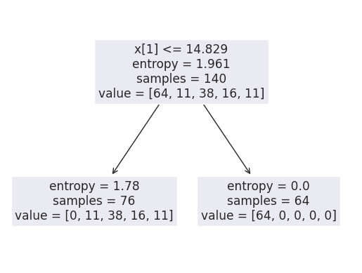

```
0.7166666666666667
```

```python
from sklearn.tree import DecisionTreeClassifier
from sklearn import metrics

tree_model = DecisionTreeClassifier(criterion='entropy',
                                    max_depth=1,
                                    random_state=1)

tree_model.fit(X_train, y_train)

X_combined = np.vstack((X_train, X_test))
y_combined = np.hstack((y_train, y_test))

tree.plot_tree(tree_model)
#plt.savefig('images/03_21_1.pdf')
plt.show()

y_pred = tree_model.predict(X_test)
print(metrics.accuracy_score(y_test, y_pred))
```

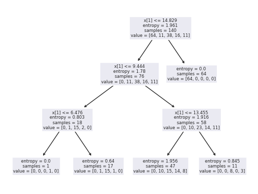

```
0.7166666666666667
```

```python
from sklearn.tree import DecisionTreeClassifier
from sklearn import metrics

tree_model = DecisionTreeClassifier(criterion='entropy',
                                    max_depth=3,
                                    random_state=1)

tree_model.fit(X_train, y_train)

X_combined = np.vstack((X_train, X_test))
y_combined = np.hstack((y_train, y_test))

tree.plot_tree(tree_model)
#plt.savefig('images/03_21_1.pdf')
plt.show()

y_pred = tree_model.predict(X_test)
print(metrics.accuracy_score(y_test, y_pred))
```

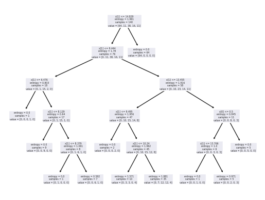

```
0.6333333333333333
```

```python
from sklearn.tree import DecisionTreeClassifier
from sklearn import metrics

tree_model = DecisionTreeClassifier(criterion='entropy',
                                    max_depth=5,
                                    random_state=1)

tree_model.fit(X_train, y_train)

X_combined = np.vstack((X_train, X_test))
y_combined = np.hstack((y_train, y_test))

tree.plot_tree(tree_model)
#plt.savefig('images/03_21_1.pdf')
plt.show()

y_pred = tree_model.predict(X_test)
print(metrics.accuracy_score(y_test, y_pred))
```

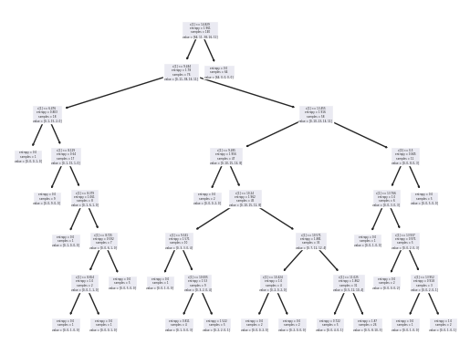

```
0.5833333333333334
```

```python
from sklearn.tree import DecisionTreeClassifier
from sklearn import metrics

tree_model = DecisionTreeClassifier(criterion='entropy',
                                    max_depth=7,
                                    random_state=1)

tree_model.fit(X_train, y_train)

X_combined = np.vstack((X_train, X_test))
y_combined = np.hstack((y_train, y_test))

tree.plot_tree(tree_model)
#plt.savefig('images/03_21_1.pdf')
plt.show()

y_pred = tree_model.predict(X_test)
print(metrics.accuracy_score(y_test, y_pred))
```

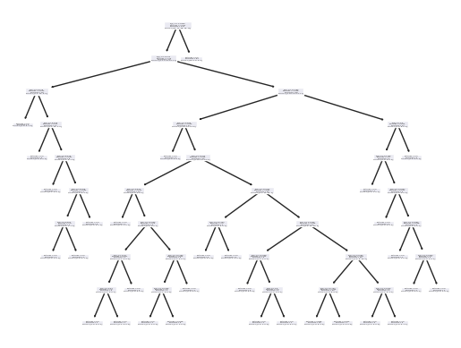

```
0.6166666666666667
```

```python
from sklearn.tree import DecisionTreeClassifier
from sklearn import metrics

tree_model = DecisionTreeClassifier(criterion='entropy',
                                    max_depth=9,
                                    random_state=1)

tree_model.fit(X_train, y_train)

X_combined = np.vstack((X_train, X_test))
y_combined = np.hstack((y_train, y_test))

tree.plot_tree(tree_model)
#plt.savefig('images/03_21_1.pdf')
plt.show()

y_pred = tree_model.predict(X_test)
print(metrics.accuracy_score(y_test, y_pred))
```

To summarize, we found the following:

Depth of 1, accuracy of 71.7%

Depth of 3, accuracy of 71.7%

Depth of 5, accuracy of 63.3%

Depth of 7, accuracy of 58.3%

Depth of 9, accuracy of 61.7%